# PHI ARFP 2023: Introduction to R

Jessica Godwin

June 22, 2023

# Getting started

## Download R

What is `R`? Open-source, free, stastical computing software.

Go to the [R website](https://cran.r-project.org/), and download the appropriate software for your operating system.

[figure not shown]

## Download RStudio

What is Rstudio? A nice GUI (graphical user interface) for writing code, analyzing data and building packages with `R`.

Go to the [RStudio website](https://rstudio.com/products/rstudio/download/#download). and download the appropriate software for your operating system.

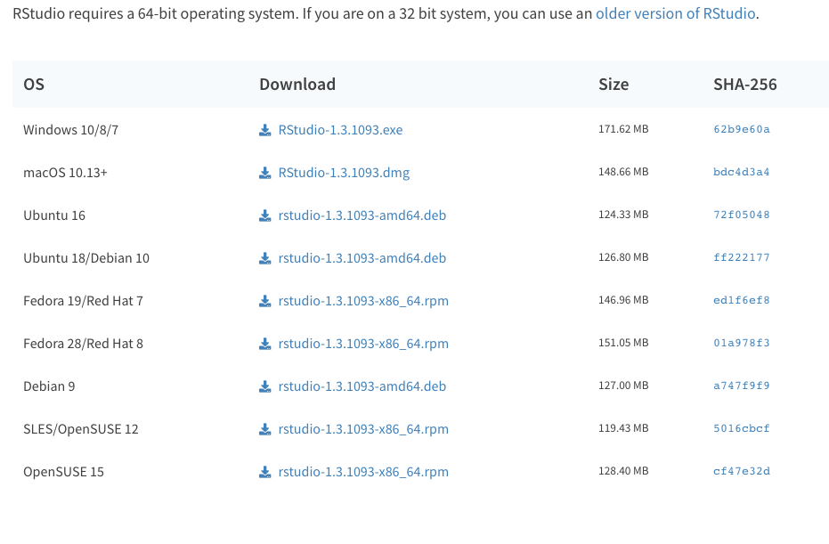

## Rstudio Layout

Rstudio has four main panels that allow you to organize your code and have a better user experience developing and using `R` code:

- Source panel: where scripts are edited
- Console panel: where code is executed and output is printed
- Environment panel: where objects are stored
- Files/Plots/Help: navigate files and folders, view plots, read and access help documentation for packages and functions

[figure not shown]

# R as a calculator

Open a new .R script by clicking File $\rightarrow$ New File $\rightarrow$ R Script. We can execute code by highlighting it in a source file and clicking the run button.

[figure not shown]

We can also execute code by typing it directly into the console and pressing enter.

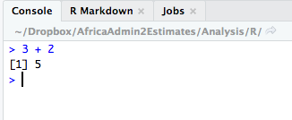

We can do basic mathematical computations using +,-, *, /, and ().

Note: `pi` is hard coded into `R`.

```r
2+3
```

```
## [1] 5
```

```r
6*7
```

```
## [1] 42
```

```r
pi*1
```

```
## [1] 3.141593
```

```r
6*3/2-3
```

```
## [1] 6
```

```r
6*3/(2-3)
```

```
## [1] -18
```

```r
1/0
```

```
## [1] Inf
```

Try some on your own!

What about more complicated functions like exsponents, square roots, trig functions and the natural logarithm?

```r
3^2
```

```
## [1] 9
```

```r
2^(3+2)
```

```
## [1] 32
```

```r
sqrt(9)
```

```
## [1] 3
```

```r
sin(2*pi)
```

```
## [1] -2.449213e-16
```

```r
log(1000)
```

```
## [1] 6.907755
```

```r
exp(6.907755)
```

```
## [1] 999.9997
```

# Documentation

```r
?log
help("log")
```

**Question** According to the above help files, what function (or functions) would you need to use for a base 10 logarithm?

There are a few other functions that can help you understand how to use functions or recall their arguments.

```r
help.search("log")
args(log)
```

# Objects in R

Numbers, formulas, and other statistical information can be stored as objects in R.

Objects are given names and then are stored in the working environment. Once they are stored, the information remainds “hidden” until referenced again. If you are using RStudio the object names can be seen in the Environment module.

Notes:

- Object names are case-sensitive
- Object names should be meaningful and short (``best practice’’)
- `<-` is most common, but `=` is acceptable

```r
x <- 2 #Creates the object "x"
x    #Shows the contents of object "x"
```

```
## [1] 2
```

```r
y = 3.5
y
```

```
## [1] 3.5
```

```r
h <- "practice"  #You can also put strings in an object
h
```

```
## [1] "practice"
```

Objects can be numbers, strings, matrices, or even more complicated `R` objects.  
Examples of `R` object types:

- the computing basics: integer, numeric, vector, matrix, list
- data.frame
- factor
- lm object (linear model object)
- formula

There are handy functions for seeing whether or not an object is of a certain type. These functions are usually important for debugging and making sure you are inputing the proper object type into a function argument.

```r
is.integer(y)
```

```
## [1] FALSE
```

```r
is.numeric(y)
```

```
## [1] TRUE
```

```r
is.character(h)
```

```
## [1] TRUE
```

```r
is.matrix(x)
```

```
## [1] FALSE
```

```r
ls()
```

```
## [1] "h" "x" "y"
```

```r
x     #Original object that we created above.
```

```
## [1] 2
```

```r
x <- 7  #New object with same name
x     #New object
```

```
## [1] 7
```

# R Markdown

Markdown is a simple formatting syntax for authoring HTML, PDF, and MS Word documents. For more details on using R Markdown see http://rmarkdown.rstudio.com. RMarkdown is a nice program within RStudio that allows us to typset documents and incorporate code and output. This is helpful for writing labs for you all to follow along with, but also to create reproducible and replicable research. It allows you to avoid writing scripts to produce all your output and then copy and pasting that output into a word processing software which may induce unnecessary errors in your work.

Go to File $\rightarrow$ New File $\rightarrow$ R Markdown. Select `Knit to HTML`

[figure not shown]

It will open up a new template .Rmd file for you to begin editing that will look like this:

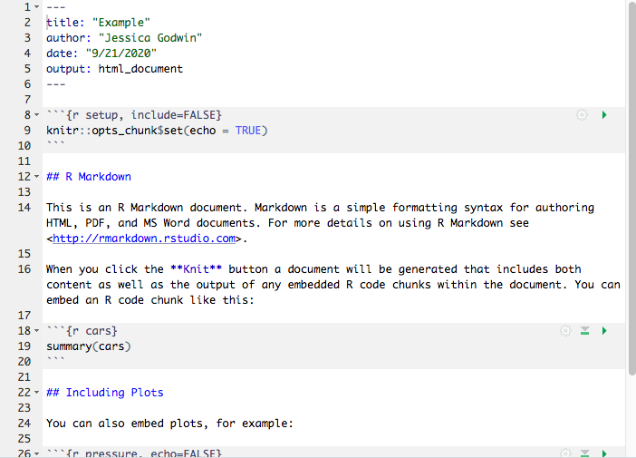

```r
data(cars)
summary(cars)
```

```
##      speed           dist
##  Min.   : 4.0   Min.   :  2.00
##  1st Qu.:12.0   1st Qu.: 26.00
##  Median :15.0   Median : 36.00
##  Mean   :15.4   Mean   : 42.98
##  3rd Qu.:19.0   3rd Qu.: 56.00
##  Max.   :25.0   Max.   :120.00
```

A handy Rstudio/R Markdown cheatsheet can be found here https://rstudio.com/wp-content/uploads/2016/03/rmarkdown-cheatsheet-2.0.pdf. It gives summaries of the most used Markdown syntax aspects (e.g. headings/subheadings, bullet lists, numbered lists), the types of files R Markdown can create and examples of how R and R Markdown interact.

This is an example of an an R Markdown file that will be used to create a .html file. This is the best option if you don’t have much math to write or do not need to share a .pdf.